# Lending Club

Alvaro Rodríguez

20 Noviembre 2018

[figure not shown]

# 1 Resumen ejecutivo

Análisis de los datos de LENDING CLUB -plataforma de préstamos entre particulares- correspondientes al cuarto trimestre de 2016 con el objeto de predecir que deudores incumplirán las obligaciones de pago de sus respectivos créditos.

En primer lugar, analizamos la base de datos. Una vez escogidas las variables, entrenamos un modelo una regresión logística y testeamos su capacidad predictiva.

Dado que la muestra está claramente desbalanceada, se llevan a cabo métodos de regularización para mejorar la eficiencia. El método que mejor precisión nos permite es LASSO.

# 2 Objetivos

El objeto de este informe es predecir los “Default” o incumplimientos que se producirán en la cartera de créditos de “LENDING CLUB” (LC en adelante), con base en las distintas variables explicativas que tenemos disponibles.

# 3 Datos

La información correspondiente al cuarto trimestre de 2016 de LC. Se encuentra disponible en el siguiente enlace:

https://www.lendingclub.com/info/download-data.action

Los datos constan inicialmente de 103.548 observaciones y 145 variables.

**Variables sin valor predictivo**: Las variables (“member_id”, “ISIN”, “url”) tienen un valor identificativo, pero no resultan relevantes para ser considerados en adelante.

**Variables con valores vacíos**: Muchas de las variables tienen valores vacíos, observándose que algunas de ellas tienes unos pocos valores vacíos y otras tienen todos o la gran mayoría. No se han considerado aquellas variables con más del 10 % de valores vacíos, precisamente para eliminar solo aquellas variables con mayor cantidad de valores vacíos.

**Dimension final** Así las cosas, La dimensión inicial era de 103548 filas, por 145 columnas. Después de eliminar las variables vacías, la dimensión era de: 103548 filas y 99 columnas. Por último, después de eliminar las observaciones con algún campo vacío, la dimensión definitiva es 87809 filas y 99 columnas.

# 4 Análisis exploratorio de datos

Exploramos aquellas variables que resultan más interesantes:

- La variable que se va a utilizar como variable dependiente ($y$) es **“loan_status”**. Esta columna del dataset describe el estado en el que se encuentra cada uno de los créditos.

```
## -------------------------------------------------------------------------
## PORTFOLIO 2016 Q4 - Loan Status
##
##   length      n    NAs unique levels  dupes
##   87'809 87'809      0      7      7      y
##          100.0%   0.0%
##
##                 level    freq   perc  cumfreq  cumperc
## 1             Current  45'059  51.3%   45'059    51.3%
## 2          Fully Paid  31'261  35.6%   76'320    86.9%
## 3         Charged Off   8'716   9.9%   85'036    96.8%
## 4  Late (31-120 days)   1'570   1.8%   86'606    98.6%
## 5     In Grace Period     815   0.9%   87'421    99.6%
## 6   Late (16-30 days)     386   0.4%   87'807   100.0%
## 7             Default       2   0.0%   87'809   100.0%
```

- En el siguiente gráfico, se relacionan las variables cantidad prestada (“loan_amnt”) y estatus de los créditos.

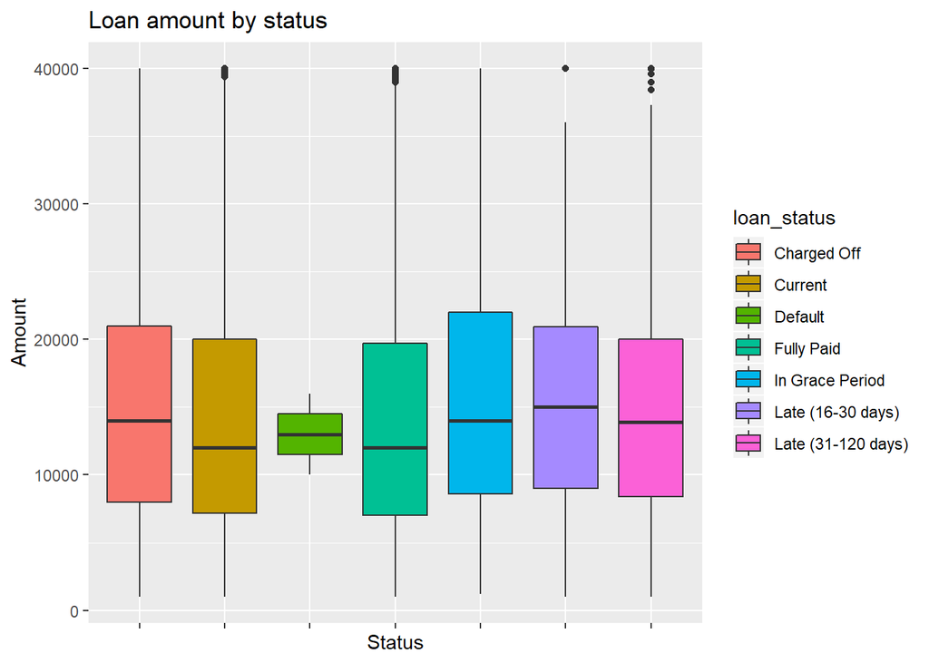

- Asimismo, LC ya asigna un **“grade”** o grado de calificación de cada crédito. Este es previsiblemente uno de los factores claves que no ayudará a predecir los incumplimientos, los valores van desde A (mínimo riesgo) hasta G (máximo riesgo).

```
## -------------------------------------------------------------------------
## PORTFOLIO 2016 Q4 - Grades
##
##   length      n    NAs unique levels  dupes
##   87'809 87'809      0      7      7      y
##          100.0%   0.0%
##
##    level    freq   perc  cumfreq  cumperc
## 1      C  29'891  34.0%   29'891    34.0%
## 2      B  27'413  31.2%   57'304    65.3%
## 3      D  13'128  15.0%   70'432    80.2%
## 4      A  11'313  12.9%   81'745    93.1%
## 5      E   4'354   5.0%   86'099    98.1%
## 6      F   1'301   1.5%   87'400    99.5%
## 7      G     409   0.5%   87'809   100.0%
```

- Los tipos de interés (**int_rate**) aplicados que también resultan verdaderamente interesantes, ya que aquellos deudores con más riesgo se les exigirá (previsiblemente) un mayor interés en el pago.

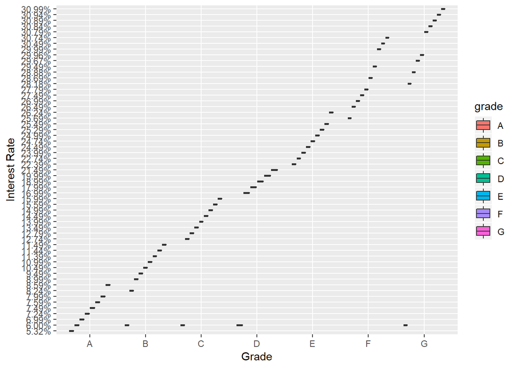

- Se visualiza el propósito para el que se solicita cada crédito (“purpose”), se representa el volumen de créditos que se ha concedido en cada categoría (“loan_amnt”) y además, se identifica el estatus en el que se encuentran (“loan_status”).

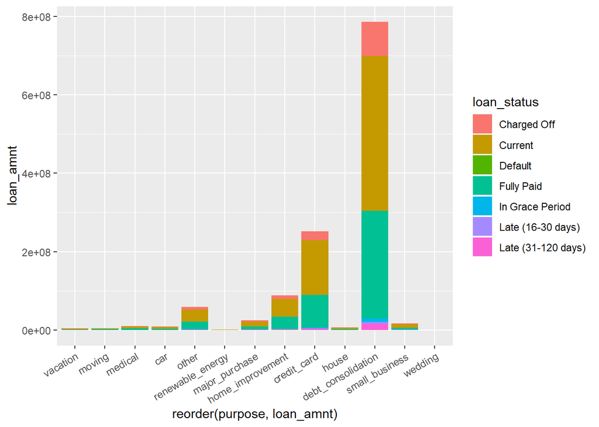

# 5 Tratamiento previo al análisis

# 6 Regresión logística

Llegados a este punto, realizamos la regresión logística. Para ello se utiliza un 70% de la muestra como datos de entrenamiento, mientras que el 30 % restante se usa para testear el modelo resultante.

Se hace uso del método de selección de variables “stepwise” mixto, que nos permite con la selección anterior de variables, reducir el modelo, mejorando la bondad del ajuste conforme al criterio de información de Akaike.

El modelo usado finalmente es: loan_status ~ grade + open_acc + pub_rec + dti + delinq_2yrs + inq_last_6mths + emp_length + annual_inc + home_ownership + addr_state + loan_amnt + revol_bal + revol_util.

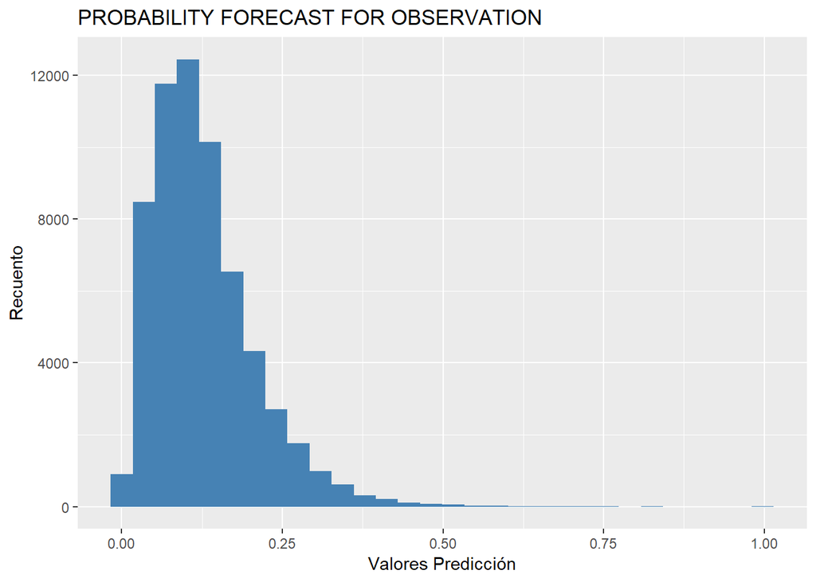

Se observa que la mayoría de créditos tienen valores cercanos a cero (No default), mientras que muy pocos de ellos rebasan el 0.5 de valor predicho por la regresión logística.

# 7 Predicción sobre la regresión logística

A partir de aquí, es preciso establecer una regla de decisión. n este caso habría que valorar el riesgo de conceder un crédito a una persona que finalmente no pueda pagarlo contra el riesgo de rechazar a alguien que pudiera haber cumplido sus obligaciones. Si estableciéramos esta regla de decisión(“cut-off”) en 0.2, y predijéramos con las variables entrenadas sobre la parte de test, obtendríamos los siguientes resultados:

```
## Confusion Matrix and Statistics
##
##           Reference
## Prediction     0     1
##          0 20089  2949
##          1  2227  1078
##
##                Accuracy : 0.8035
##                  95% CI : (0.7987, 0.8083)
##     No Information Rate : 0.8471
##     P-Value [Acc > NIR] : 1
##
##                   Kappa : 0.1812
##  Mcnemar's Test P-Value : <2e-16
##
##             Sensitivity : 0.9002
##             Specificity : 0.2677
##          Pos Pred Value : 0.8720
##          Neg Pred Value : 0.3262
##              Prevalence : 0.8471
##          Detection Rate : 0.7626
##    Detection Prevalence : 0.8745
##       Balanced Accuracy : 0.5839
##
##        'Positive' Class : 0
##
```

El poder de predicción del modelo logístico con este cut-off es limitado. Los errores de clasificación en el modelo logístico son relevantes.

Se muestra la curva ROC del modelo logístico para el cut-off 0.2. Nuevamente observamos como el valor clasificador del modelo es poco significativo.

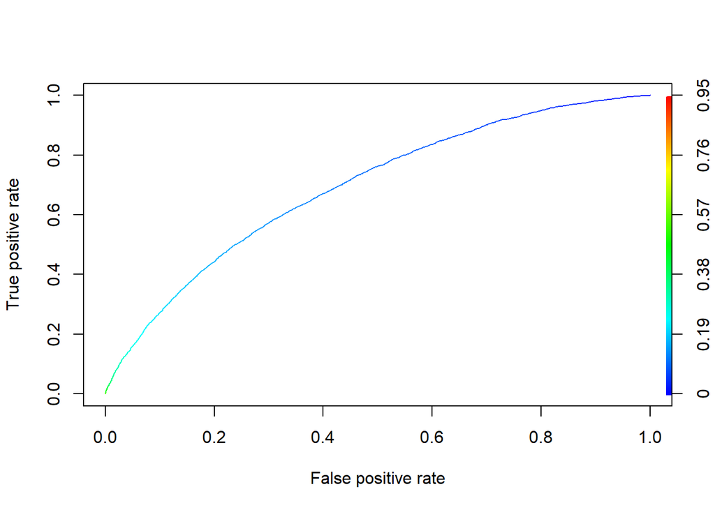

# 8 Conclusión regresión logística

Mediante una regresión logística basada en las distintas variables de los deudores que se mostraban más arriba, es posible prever -con un error cercano al 20%- que créditos han de otorgarse y cuales no si queremos evitar futuros incumplimientos. El modelo dispone de un hiper-parámetro de corte, en función del cual podemos adaptar la sensibilidad del modelo.

# 9 Regularización

Dado que la muestra esta claramente desbalanceada, llevamos a cabo métodos de regularización para mejorar la predicción que hemos llevado a cabo. Podemos aplicar tanto una regresión Ridge (penaliza la inclusión de variables sin eliminarlas, pese a que sus coeficientes sean muy cercanos a cero), una regresión LASSO (nos permite descartar variables) o una regresión elasticnet, que conjuga carácterísticas de uno y otro.

Para averiguar cual de las regresión es la que mejor se ajusta a nuestra muestra, probamos tanto Ridge como LASSO, como elastic net con distinto valores para $\alpha$. Se ha mantenido una muestra de entrenamiento del 70% y una muestra de test del 30%.

Se selecciona la regresión que nos da el menor error cuadrático medio en la cross validation que he llevado a cabo (k.folds(8)).

| alpha | mse_min | mse_1se | lambda_min | lambda_1se |
| --- | --- | --- | --- | --- |
| 0.0 | 0.7092120 | 0.7119993 | 0.0077216 | 0.0656148 |
| 0.1 | 0.7083392 | 0.7110441 | 0.0003117 | 0.0205093 |
| 0.2 | 0.7083158 | 0.7111595 | 0.0007579 | 0.0135561 |
| 0.3 | 0.7082581 | 0.7112204 | 0.0008830 | 0.0099185 |
| 0.4 | 0.7082179 | 0.7110673 | 0.0008754 | 0.0074389 |
| 0.5 | 0.7081920 | 0.7109784 | 0.0007686 | 0.0059511 |
| 0.6 | 0.7081709 | 0.7109180 | 0.0007030 | 0.0049593 |
| 0.7 | 0.7081554 | 0.7108762 | 0.0006025 | 0.0042508 |
| 0.8 | 0.7081432 | 0.7108449 | 0.0005786 | 0.0037194 |
| 0.9 | 0.7081340 | 0.7111593 | 0.0005143 | 0.0036285 |
| 1.0 | 0.7081256 | 0.7111387 | 0.0004629 | 0.0032657 |

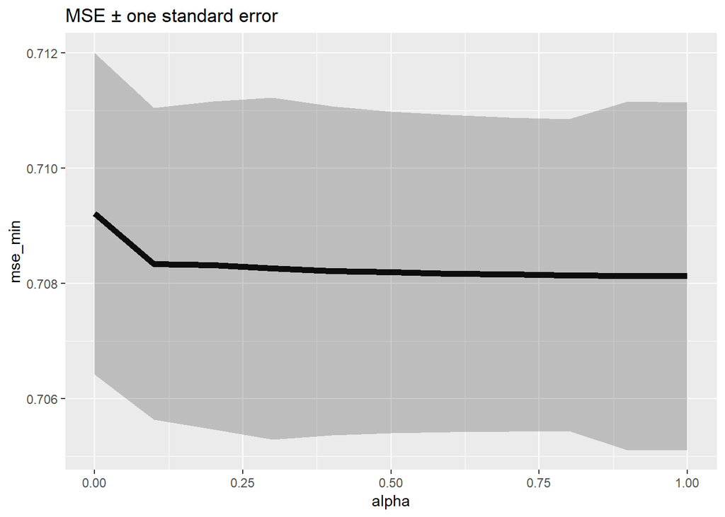

Conforme a la tabla y gráfico anteriores, concluímos que Lasso será la regresión que nos da mayor precisión.

# 10 Regresión LASSO

En primer lugar visualizamos el coeficiente que LASSO aplica a cada una de las variables y como se van seleccionando.

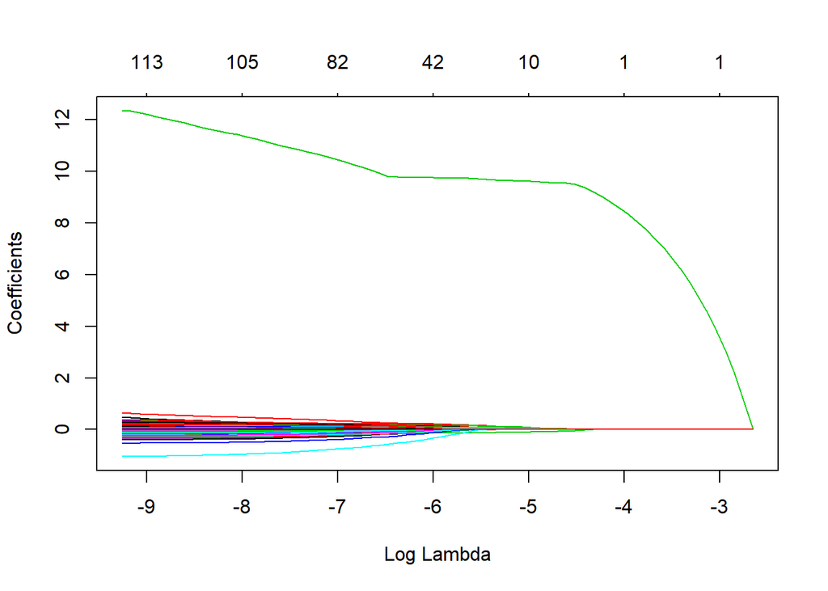

Analizamos el cross validation que se ha llevado a cabo y los distintos resultados. Seleccionamos el modelo con las mínimas variables dentro de una desviación típica, ya que estadísticamente es equivalente a seleccionar el error mínimo de todas las validaciones.

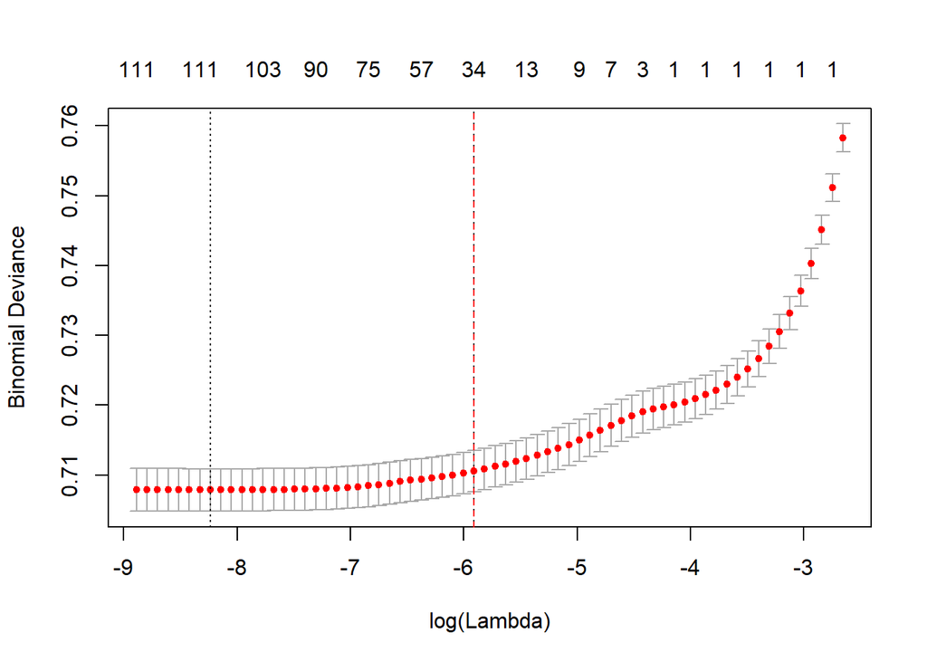

Representamos las variables seleccionadas por el modelo.

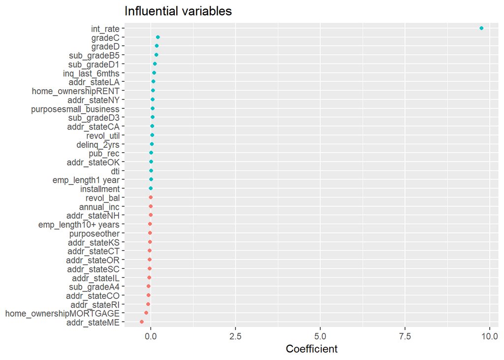

# 11 Conclusiones

Cuando nos encontramos con muestras desbalanceadas o con problema de multicolinealidad, resulta conveniente llevar a cabo una regularización de los datos para mejorar la precisión de las estimaciones.